# Sparkify Project

#### Number of events as a paid user

```python
paid_event = udf(lambda x: 1 if x == 'paid' else 0, IntegerType())
df_model = df_model.withColumn('paidEvent', paid_event('level'))

df_paid = df_model \
    .select('userId','churn','paidEvent') \
    .groupby('userId','churn').agg({'paidEvent':'sum'}) \
    .withColumnRenamed('sum(paidEvent)','numPaid') \
    .toPandas()
```

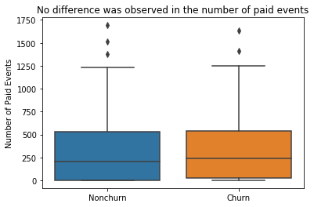

```python
box_plot(df_paid, 'numPaid',
         'Number of Paid Events',
         'No difference was observed in the number of paid events')
```

#### Number of ads

```python
roll_advert = udf(lambda x: 1 if x == 'Roll Advert' else 0, IntegerType())
df_model = df_model.withColumn('ads', roll_advert('page'))

df_ads = df_model \
    .select('userId','churn','ads') \
    .groupby('userId','churn').agg({'ads':'sum'}) \
    .withColumnRenamed('sum(ads)','numAds') \
    .toPandas()
```

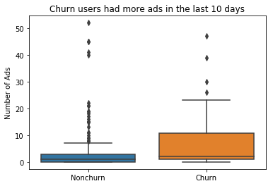

```python
box_plot(df_ads, 'numAds',
         'Number of Ads',
         'Churn users had more ads in the last 10 days')
```

#### User's gender

```python
df_gender = df_model.select('userId','churn','gender').dropDuplicates().toPandas()
```

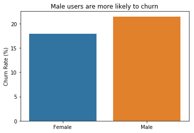

```python
female_churn = df_gender[(df_gender.churn == 1) & (df_gender.gender == 'F')].shape[0]/df_gender[df_gender.gender == 'F'].shape[0] *100
male_churn = df_gender[(df_gender.churn == 1) & (df_gender.gender == 'M')].shape[0]/df_gender[df_gender.gender == 'M'].shape[0] *100

sns.barplot([0,1], [female_churn, male_churn])
plt.xticks([0,1], ['Female','Male'])
plt.ylabel('Churn Rate (%)')
plt.title('Male users are more likely to churn');
```

The result is a little surprising that churn users were slightly more active in the last 10 days by spending more time on the service, listening more songs, adding more songs and friends. But they also had more thumbs down, downgrades and ads.

I decide to use the following features to train my model:

1. user's gender
- days being a user
- number of thumbs down
- number of downgrades
- number of ads

Write a scalable script to create necessary new columns and filter data.

```python
def filter_data(df):
    """
    Create necessary new columns and filter data to include the most recent 10 days of data

    INPUT:
        df - clean df

    OUTPUT:
        df - df with the most recent 10 days of data
    """
    # create a new column churn
    flag_churn_event = udf(lambda x: 1 if x == 'Cancellation Confirmation' else 0, IntegerType())
    df = df.withColumn('churnEvent', flag_churn_event('page'))

    windowval = Window.partitionBy('userId')
    df = df.withColumn('churn', max('churnEvent').over(windowval))

    # create a new column dataRange
    df = df.withColumn('dataRange',
                       ((max('ts').over(windowval)-min('ts').over(windowval))/1000/3600/24).cast('int'))

    # create a new column countDown
    df = df.withColumn('lastEvent', max('ts').over(windowval))
    df = df.withColumn('countDown', ((df.lastEvent-df.ts)/1000/3600/24).cast('int'))

    # filter data
    df = df.filter((df.dataRange >= 10) & (df.countDown <= 10))

    # create a new column thumbDown
    thrumb_down = udf(lambda x: 1 if x == 'Thumbs Down' else 0, IntegerType())
    df = df.withColumn('thumbDown', thrumb_down('page'))

    # create a new column downgrade
    downgrade = udf(lambda x: 1 if x == 'Downgrade' else 0, IntegerType())
    df = df.withColumn('downgrade', downgrade('page'))

    # create a new column ads
    roll_advert = udf(lambda x: 1 if x == 'Roll Advert' else 0, IntegerType())
    df = df.withColumn('ads', roll_advert('page'))

    return df
```

# Feature Engineering

```python
# convert gender to numerical values F: 0, M: 1
df_gender = df_model \
    .select('userId','gender').dropDuplicates() \
    .replace({'F':'0', 'M':'1'}, subset='gender') \
    .select('userId', col('gender').cast('int'))
```

```python
df_servicedays = df_model \
    .select('userId','churn','registration','ts') \
    .withColumn('serviceDays', (df_model.ts - df_model.registration)) \
    .groupby('userId','churn').agg({'serviceDays':'max'}) \
    .select('userId','churn',(col('max(serviceDays)')/1000/3600/24).cast('int').alias('serviceDays'))
```

```python
thrumb_down = udf(lambda x: 1 if x == 'Thumbs Down' else 0, IntegerType())
df_model = df_model.withColumn('thumbDown', thrumb_down('page'))

df_thumbdown = df_model \
    .select('userId','thumbDown') \
    .groupby('userId').agg({'thumbDown':'sum'}) \
    .withColumnRenamed('sum(thumbDown)','numThumbdown')
```

```python
downgrade = udf(lambda x: 1 if x == 'Downgrade' else 0, IntegerType())
df_model = df_model.withColumn('downgrade', downgrade('page'))

df_downgrade = df_model \
    .select('userId','downgrade') \
    .groupby('userId').agg({'downgrade':'sum'}) \
    .withColumnRenamed('sum(downgrade)','numDowngrade')
```

```python
roll_advert = udf(lambda x: 1 if x == 'Roll Advert' else 0, IntegerType())
df_model = df_model.withColumn('ads', roll_advert('page'))

df_ads = df_model \
    .select('userId','ads') \
    .groupby('userId').agg({'ads':'sum'}) \
    .withColumnRenamed('sum(ads)','numAds')
```

```python
# combine all features, drop userId and rename churn with label
data = df_gender.join(df_servicedays, 'userID') \
    .join(df_thumbdown, 'userID') \
    .join(df_downgrade, 'userID') \
    .join(df_ads, 'userID') \
    .drop('userID') \
    .withColumnRenamed('churn','label')
data.show(5)
```

```
+------+-----+-----------+------------+------------+------+
|gender|label|serviceDays|numThumbdown|numDowngrade|numAds|
+------+-----+-----------+------------+------------+------+
|     0|    0|         55|           1|           0|     2|
|     1|    0|         70|           0|           2|     0|
|     0|    0|        131|           5|           4|     0|
|     1|    1|         19|          15|          13|     0|
|     1|    0|         72|           0|           0|     1|
+------+-----+-----------+------------+------------+------+
only showing top 5 rows
```

Write a scalable script to extract features.

```python
def extract_feature(df):
    """
    Create a new df with extracted features

    INPUT:
        df - df with filtered data

    OUTPUT:
        data - new df with extracted features and label
    """
    # convert gender to numerical values F: 0, M: 1
    df_gender = df \
        .select('userId','gender').dropDuplicates() \
        .replace({'F':'0', 'M':'1'}, subset='gender') \
        .select('userId', col('gender').cast('int'))

    # extract days being a user
    df_servicedays = df \
        .select('userId','churn','registration','ts') \
        .withColumn('serviceDays', (df.ts - df.registration)) \
        .groupby('userId','churn').agg({'serviceDays':'max'}) \
        .select('userId','churn',(col('max(serviceDays)')/1000/3600/24).cast('int').alias('serviceDays'))

    # extract number of thumbs down
    df_thumbdown = df \
        .select('userId','thumbDown') \
        .groupby('userId').agg({'thumbDown':'sum'}) \
        .withColumnRenamed('sum(thumbDown)','numThumbdown')

    # extract number of downgrades
    df_downgrade = df \
        .select('userId','downgrade') \
        .groupby('userId').agg({'downgrade':'sum'}) \
        .withColumnRenamed('sum(downgrade)','numDowngrade')

    # extract number of ads
    df_ads = df \
        .select('userId','ads') \
        .groupby('userId').agg({'ads':'sum'}) \
        .withColumnRenamed('sum(ads)','numAds')

    # combine all features, drop userId and rename churn with label
    data = df_gender.join(df_servicedays, 'userID') \
        .join(df_thumbdown, 'userID') \
        .join(df_downgrade, 'userID') \
        .join(df_ads, 'userID') \
        .drop('userID') \
        .withColumnRenamed('churn','label')

    return data
```

### Transform skewed numerical features

A dataset may contain features whose values tend to lie near a single number, but also have non-trivial values vastly larger or smaller than that single number. Algorithms can be sensitive to such distributions of values and can underperform if the range is not properly normalized. I will check the skewness of all of the numerical features. For highly-skewed feature distributions, I will apply a **log transformation** on the data to reduce the range of values caused by outliers thereby improving the model's performance. I need to translate the values by a small amount above 0 (e.g. 0.01) because the logarithm of 0 is undefined.

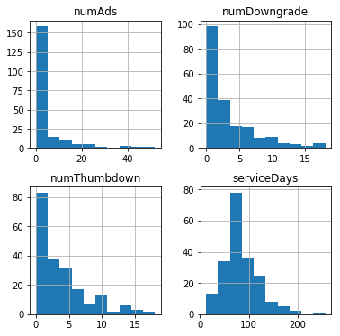

```python
# check the skewness of numerical features
data_pd = data.toPandas()
num_data = data_pd.drop(['gender','label'], axis=1)
num_data.hist(figsize=(6,6));
```

```python
# apply log transformation to skewed features
skewed = ['numAds', 'numDowngrade', 'numThumbdown']

for col in skewed:
    data_pd[col] = data_pd[col].astype('float64').replace(0.0, 0.01)
    data_pd[col] = np.log(data_pd[col])
```

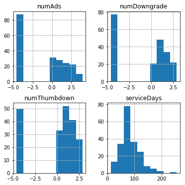

```python
num_data = data_pd.drop(['gender','label'], axis=1)
num_data.hist(figsize=(6,6));
```

### Check multicollinearity among numerical features

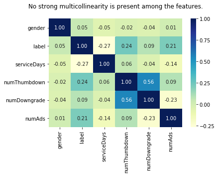

```python
# check if multicollinearity is present
corr = data_pd.corr()
sns.heatmap(corr, annot=True, fmt='.2f', cmap='YlGnBu')
plt.title('No strong multicollinearity is present among the features.\n');
```

```python
# convert pandas df to spark df
data_spark = spark.createDataFrame(data_pd)
```

```python
data_spark.head()
```

```
Row(gender=0, label=0, serviceDays=55, numThumbdown=0.0, numDowngrade=-4.605170185988091, numAds=0.6931471805599453)
```

### Combine features to a vector

```python
# combine features to a vector
cols = data_spark.drop('label').columns
assembler = VectorAssembler(inputCols=cols, outputCol='numFeatures')
data_spark = assembler.transform(data_spark)
```

```python
data_spark.head()
```

```
Row(gender=0, label=0, serviceDays=55, numThumbdown=0.0, numDowngrade=-4.605170185988091, numAds=0.6931471805599453, numFeatures=DenseVector([0.0, 55.0, 0.0, -4.6052, 0.6931]))
```

### Scaling numerical features

In addition to performing transformations on highly skewed features, I will also perform scaling on numerical features. Scaling will not change the shape of the feature distribution but ensure that each feature is treated equally when applying a learning model.

```python
# standardize the vectors
scaler = StandardScaler(inputCol='numFeatures', outputCol='features', withStd=True)
scalerModel = scaler.fit(data_spark)
data_spark = scalerModel.transform(data_spark)
```

```python
data_spark.head()
```

```
Row(gender=0, label=0, serviceDays=55, numThumbdown=0.0, numDowngrade=-4.605170185988091, numAds=0.6931471805599453, numFeatures=DenseVector([0.0, 55.0, 0.0, -4.6052, 0.6931]), features=DenseVector([0.0, 1.5226, 0.0, -1.5595, 0.2222]))
```

### Split data

```python
train, test = data_spark.randomSplit([0.8, 0.2], seed=42)
```

Write a scalable script to preprocess data for model training.

```python
def preprocess(data):
    """
    Preprocess data for model training: transform skewed features,
                                        combine features,
                                        scale features,
                                        and split data

    INPUT:
        data - data containing label and features

    OUTPUT:
        train, test sets
    """
    # transform skewed features
    data_pd = data.toPandas()
    skewed = ['numAds', 'numDowngrade', 'numThumbdown']

    for col in skewed:
        data_pd[col] = data_pd[col].astype('float64').replace(0.0, 0.01)
        data_pd[col] = np.log(data_pd[col])

    # convert pandas df to spark df
    data = spark.createDataFrame(data_pd)

    # combine features to a vector
    cols = data.drop('label').columns
    assembler = VectorAssembler(inputCols=cols, outputCol='numFeatures')
    data = assembler.transform(data)

    # standardize the vectors
    scaler = StandardScaler(inputCol='numFeatures', outputCol='features', withStd=True)
    scalerModel = scaler.fit(data)
    data = scalerModel.transform(data)

    train, test = data.randomSplit([0.8, 0.2], seed=42)

    return train, test
```

# Modeling

### Baseline model

To create a baseline model, I will label all predictions as "0" because the number of churn users is small. If I predict all of them as nonchurn, I will have relatively better accuracy and F1 score.

```python
baseline = test.withColumn('prediction', lit(0.0))
```

```python
def model_eval(result, evaluator, test_set):
    """
    Display accuracy, precision, recall and F1 score of test set

    INPUT:
        result - result containing predictions (df)
        evaluator - evaluator
        test_set - name of dataset used in prediction (str)
    """
    accuracy = evaluator.evaluate(result, {evaluator.metricName: 'accuracy'})
    precision = evaluator.evaluate(result, {evaluator.metricName: 'weightedPrecision'})
    recall = evaluator.evaluate(result, {evaluator.metricName: 'weightedRecall'})
    f1 = evaluator.evaluate(result, {evaluator.metricName: 'f1'})

    print(f'\nAccuracy of {test_set} set: {accuracy}')
    print(f'Precision of {test_set} set: {precision}')
    print(f'Recall of {test_set} set: {recall}')
    print(f'F1 score of {test_set} set: {f1}')
```

```python
evaluator = MulticlassClassificationEvaluator()
model_eval(baseline, evaluator, 'test')
```

```
Accuracy of test set: 0.8275862068965517
Precision of test set: 0.6848989298454221
Recall of test set: 0.8275862068965517
F1 score of test set: 0.749512036434613
```

**The baseline model has an accuracy of 0.82 and an F1 score of 0.75**. **F1 score is a better metric** in this project because the dataset is imbalanced. I also checked precision and recall. Depending on the cost of retaining existing customers versus attracting new customers, I will decide which metric I should use.

### Model selection

I will compare three different models based on training time, accuracy and F1 score. Then I will use cross validation to minimize overfitting, and grid search to tune the model. After that, I will pick the best model based on F1 score, train it on training set, and evaluate it on test set. Finally, I will plot the feature importance.

#### Logistic regression

```python
def build_model(model, model_name):
    """
    Build a model with 3-fold cross validation and display the evaluation result

    INPUT:
        model - model with parameters
        model_name - name of the classifier (str)

    OUTPUT:
        trained_model - trained model
    """
    # initialize model
    model = model

    # build paramGrid
    paramGrid = ParamGridBuilder().build()

    crossval_model = CrossValidator(estimator=model,
                                  estimatorParamMaps=paramGrid,
                                  evaluator=MulticlassClassificationEvaluator(),
                                  numFolds=3)

    # train the training set and calculate training time
    start = time.time()
    trained_model = crossval_model.fit(train)
    end = time.time()
    train_time = end - start

    # predict the traing and validation set
    evaluator = MulticlassClassificationEvaluator()
    result_train = trained_model.transform(train)
    result_test = trained_model.transform(test)

    print(f'{model_name}')
    print(f'\nTraining time: {train_time} seconds')
    model_eval(result_train, evaluator, 'train')
    model_eval(result_test, evaluator, 'test')

    return trained_model
```

```python
cvModel_lr = build_model(LogisticRegression(maxIter=10),'Logistic Regression')
```

```
Logistic Regression

Training time: 9.063603639602661 seconds

Accuracy of train set: 0.8497109826589595
Precision of train set: 0.8492218763895065
Recall of train set: 0.8497109826589596
F1 score of train set: 0.8208173306953227

Accuracy of test set: 0.896551724137931
Precision of test set: 0.9080459770114943
Recall of test set: 0.896551724137931
F1 score of test set: 0.8774268328020862
```

#### Random forest

```python
cvModel_rf = build_model(RandomForestClassifier(numTrees=10, seed=42),'Random Forest')
```

```
Random Forest

Training time: 8.108211755752563 seconds

Accuracy of train set: 0.8959537572254336
Precision of train set: 0.9079590929301911
Recall of train set: 0.8959537572254336
F1 score of train set: 0.8811308427328244

Accuracy of test set: 0.896551724137931
Precision of test set: 0.9080459770114943
Recall of test set: 0.896551724137931
F1 score of test set: 0.8774268328020862
```

#### Gradient-boosted tree

```python
cvModel_gbt = build_model(GBTClassifier(maxIter=10, seed=42),'Gradient-boosted Tree')
```

```
Gradient-boosted Tree

Training time: 19.57548713684082 seconds

Accuracy of train set: 0.9364161849710982
Precision of train set: 0.9411102921208829
Recall of train set: 0.9364161849710984
F1 score of train set: 0.9317073853463275

Accuracy of test set: 0.896551724137931
Precision of test set: 0.8906896551724138
Recall of test set: 0.896551724137931
F1 score of test set: 0.8918601923528031
```

According to the results above, I decide to choose **random forest** because:

1. it requires the least time to train
2. it performs well as logistic regression or gradient-boosted tree does
3. it generalizes better than gradient-boosted tree

```python
# deal with data imbalance
# num_nonchurn = data.filter(data.label == 0).count()
# total = data.count()

# balancingRatio = num_nonchurn / total
# balancingRatio
```

```python
# create a new column classWeight in the training set
# class_weight = udf(lambda x: balancingRatio if x == 1 else (1 - balancingRatio), FloatType())
# train = train.withColumn('classWeight', class_weight('label'))
```

### Tune hyperparameters

```python
clf = RandomForestClassifier(seed=42)

paramGrid = ParamGridBuilder() \
    .addGrid(clf.maxDepth, [5,10,20]) \
    .addGrid(clf.numTrees, [10,20,30]) \
    .build()

crossval = CrossValidator(estimator=clf,
                          estimatorParamMaps=paramGrid,
                          evaluator=MulticlassClassificationEvaluator(),
                          numFolds=3)
```

```python
start = time.time()
cvModel = crossval.fit(train)
end = time.time()

print(f'Tuning time: {end - start} seconds')
cvModel.avgMetrics
```

```
Tuning time: 27.35025954246521 seconds
```

```
[0.7908335492233258,
 0.8056336225979894,
 0.8130756951508669,
 0.7710195315010041,
 0.8025356535682788,
 0.7756793788316765,
 0.7710195315010041,
 0.8025356535682788,
 0.7756793788316765]
```

```python
evaluator = MulticlassClassificationEvaluator()
final_result = cvModel.transform(test)
model_eval(final_result, evaluator, 'test')
```

```
Accuracy of test set: 0.896551724137931
Precision of test set: 0.8906896551724138
Recall of test set: 0.896551724137931
F1 score of test set: 0.8918601923528031
```

```python
(0.89 - 0.75)/0.75
```

```
0.18666666666666668
```

```python
try:
    cvModel.save('final_clf')
except:
    cvModel.write().overwrite().save('final_clf')
```

After hyperparameter tuning, **the final model results in an F1 score of 0.89 with 19% improvement from baseline**.

```python
# load trained_model
# cvModel = CrossValidatorModel.load('final_clf')
```

### Feature importance

```python
best_model = cvModel.bestModel
```

```python
cols = np.array(data.drop('label').columns)
```

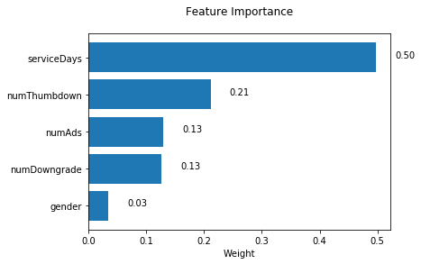

```python
importances = best_model.featureImportances.values
indices = np.argsort(importances)
values = importances[indices]
labels = cols[indices]
locs = np.arange(len(cols))

plt.barh(locs, values, align='center')
plt.yticks(locs, labels)
plt.xlabel('Weight')
plt.title('Feature Importance\n');

# Add annotation
for loc, wt in zip(locs, values):
    s = f'{wt:0.2f}'
    plt.text(y=loc, x=wt+0.05, s=s, ha='center')
```

# Summary and Conclusion

In summary, **days being a user, number of thumbs down and number of advertisements** are the top 3 important features in predicting Sparkify customer churn.